# Prática no R! Roteiro 1 - Introdução ao Software R/RStudio

Elaborado por Luis Felipe Bortolatto da Cunha

21 de setembro de 2020

# 1. Introdução

Ao longo deste curso, os softwares R/RStudio serão usados como uma **ferramenta** para auxiliar na aplicação de **métodos e técnicas de análise da informação no planejamento**, uma etapa fundamental em pesquisas que buscam o aumento da compreensão de questões no nosso campo de interesse.

É importante ressaltar o uso do R/RStudio não pode ser dissociado do **processo de pesquisa**, que envolve a observação, formulação de hipóteses, coleta de dados e **análise de dados**, sendo este o foco deste curso.

# 2. O que é o R?

O **R** é um **programa estatístico** muito útil na **análise e visualização de dados**, onde a interação é feita através de uma **sintaxe** (linguagem de programação).

Algumas de suas vantagens são:

- É **gratuito**, de **distribuição livre** e de **código aberto**
- Possui uma **curva de aprendizado bastante amigável**, sendo muito fácil de se aprender (se comparado a outros programas estatísticos)
- Todas as rotinas criadas em R são **transparentes**, seguindo os princípios da ciência aberta
- Existe uma enorme quantidade de **pacotes** gratuitos, para diversos tipos de aplicações
- Existe uma enorme quantidade de **ajuda e tutoriais** disponíveis gratuitamente na internet
- É amplamente utilizado pela **comunidade acadêmica** e mercado

Um **script** refere-se à uma rotina de análise ou visualização de dados que:

- É um texto
- É reprodutível
- Pode ser compartilhado
- Pode ser colaborativo

# 3. O que é o RStudio?

O **RStudio** é o **ambiente de desenvolvimento integrado** mais utilizado na análise de dados com a linguagem de programação R. Além de permitir **escrever códigos em scripts** e **executar códigos no console**, é possível visualizar gráficos e mapas (estáticos ou dinâmicos), gerenciar pacotes, navegar pelos arquivos, dentre outras funções.

# 4. Instalando o R e RStudio

Primeiro, é necessário instalar o R. Você pode transferir a última versão [neste endereço](https://cran.r-project.org/bin/windows/base/). Após a transferência, siga o passo a passo para a instalação.

Se a instalação do R foi bem sucedida, você pode transferir o RStudio Desktop (versão gratuita) [neste endereço](https://rstudio.com/products/rstudio/download/) e seguir o passo a passo para a instalação.

# 5. Interface RStudio

A interface do RStudio deve exibir, na maior parte do tempo, quatro painéis:

**1. Source:** É a sua área de trabalho principal. Pode exibir várias janelas, com scripts, tabelas e outros conteúdos. Ao clicar em `Run` ou apertar os comandos `Ctrl + Enter`, dentro de um script, o conteúdo selecionado será enviado ao `Console` para ser executado.

**2. Console:** Todo código que você executar em um script será enviado ao `Console`, onde os resultados e avisos aparecerão. Você também pode escrever uma linha de código diretamente no `Console`.

**3. Environment/History**:

- Environment: É o ambiente de trabalho ativo. Todos os objetos e funções definidos devem aparecer no `Environment`.
- History: Exibe o histórico de cada linha de código executada, que podem ser enviadas à `Source` ou `Console`.

**4. Files/Plots/Packages/Help:**

- Files: Permite navegar pelos diretórios de trabalho.
- Plots: Exibe os gráficos, mapas e outras figuras produzidas.
- Packages: Permite o gerenciamento dos pacotes ativos e instalados.
- Help: Contém tutoriais e exibe ajuda, quando solicitada.

[figure not shown]

Fig. 1 - Interface RStudio

# 6. Objetos

Na linguagem de programação R, os objetos são a unidade básica de análise. Eles referem-se à um pequeno espaço na memória RAM do computador onde um conjunto de valores serão armazenados. Geralmente usamos o operador `<-` ou `=` para definir um objeto.

O R suporta diferentes tipos de objetos, sendo alguns dos mais comuns:

- Vetor (`vector`): um conjunto unidimensional de valores da mesma classe.
- Matriz (`matrix`): um conjunto bidimensional de valores da mesma classe (geralmente, numérico).
- **Tabela (`data.frame` ou `tibble`)**: um conjunto bidimensional de valores, organizados em linhas e colunas. Todos os valores de uma coluna possuem a mesma classe.
- Raster (`raster`): uma matriz com atributos geoespaciais.
- Geoespacial (`sf`): uma tabela com atributos geoespaciais.
- Lista (`list`): um conjunto unidimensional de outros objetos (por exemplo, tabelas).

Nas primeiras aulas vamos explorar dados em formato de **tabela**! É nesse formato que os bancos de dados são geralmente disponibilizados na internet. As tabelas de bancos de dados sempre possuem uma estrutura comum: os valores são organizados em **linhas (observações)** e **colunas (variáveis)**, sendo consideradas um tipo de **dados estruturados**. As observações referem-se à unidade de análise (pessoas, domicílios, municípios etc.), enquanto as variáveis são os atributos dessa variável e possuem sempre a mesma classe (caractére, numérico, fator etc.).

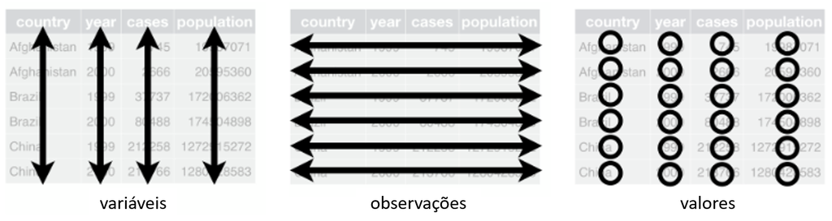

Fig. 2 - Dados estruturados. Fonte: adaptado de Grolemund & Wickham, 2017

# 7. Funções

Na linguagem de programação R, as **funções** referem-se à uma **sequência de comandos** que permitem **realizar operações complexas**. O R básico já vem com diversas funções estatísticas clássicas definidas:

- `sum()`: soma
- `mean()`: média
- `median()`: mediana
- `quantile()`: quantil
- `sd()`: desvio padrão
- `var()`: variância
- `sqrt()`: raiz quadrada
- `exp()`: exponencial
- `round()`: arredondamento

Novas funções podem ser adicionadas carregando pacotes.

# 8. Operadores matemáticos

Os **operadores aritméticos** já estão definidos na linguagem R, permitindo realizar operações com dados numéricos:

- Adição: +
- Subtração: -
- Multiplicação: *
- Divisão: /
- Módulo: %%
- Divisão por inteiro: %/%
- Exponenciação: ^ ou **

# 9. Operadores lógicos

Os **operadores lógicos** também já estão definidos na linguagem R, permitindo fazer perguntas sobre os dados e retornando sempre `TRUE` (verdadeiro) ou `FALSE` (falso).

- x **==** y: x é **igual** a y?
- x **!=** y: x é **diferente** de y?
- x **>** y: x é **maior** que y?
- x **>=** y: x é **maior ou igual** a y?
- x **<** y: x é **menor** que y?
- x **<=** y: x é **menor ou igual** a y?
- x **&** y: x **e** y são verdadeiros?
- x **|** y: x **ou** y são verdadeiros?
- **!**x: **negativa** de x.
- **is.na(**x**)**: x é **igual a NA**?
- **!is.na(**x**)**: x é **diferente de NA**?

# 10. Como buscar ajuda

No decorrer das aulas práticas, você pode precisar de ajuda para entender uma função. Não se preocupe: ter dúvidas faz parte do processo de aprendizado. Na verdade, o R/RStudio conta com uma ferramenta que pode te auxiliar: é possível acessar tutoriais produzidos pelo R/RStudio na aba `Help`.

`Help` também exibe a documentação de cada função, que pode ser acessada com o uso das funções `help()` ou `?`.

Para acessar a documentação da função média, por exemplo, você pode digitar:

```r
help(mean)
```

Ou:

```r
?mean
```

Que deve exibir o seguinte conteúdo na aba `Help`:

- **Descrição:** Função genérica para a média aritmética (aparada).
- **Uso:** mean(x, …)
- **Argumentos:**
  - **x** Um objeto R. Atualmente existem métodos para vetores numéricos / lógicos e objetos de data, hora e intervalo de tempo. Vetores complexos são permitidos apenas para trim = 0.
  - **trim** a fração (0 a 0,5) de observações a serem aparadas de cada extremidade de x antes que a média seja calculada. Os valores de corte fora desse intervalo são considerados como o ponto final mais próximo.
  - **na.rm** um valor lógico que indica se os valores de NA devem ser removidos antes que o cálculo continue.
  - **…** argumentos adicionais passados para ou de outros métodos.
- **Valor:** Se o corte for zero (o padrão), a média aritmética dos valores em x é calculada, como um vetor numérico ou complexo de comprimento um. […]

**Importante: a seção uso descreve quais são os argumentos obrigatórios (apenas x, no caso da função `mean()`), sendo todos os outros argumentos descritos opcionais. Atente-se aos argumentos obrigatórios e opcionais ao usar uma função.**

Infelizmente, a maior parte do conteúdo está escrito em inglês, assim como em outras linguagens de programação. =(

Você pode traduzir o conteúdo da documentação no tradutor de sua preferência, como fizemos para apresentar a documentação da função `mean()`.

Você também pode buscar ajuda em um buscador (Google, Bing, Yahoo etc.), pois já existem diversos materiais em português sobre a linguagem de programação R e análise de dados, mas estaremos disponíveis para tirar quaisquer eventuais dúvidas no decorrer deste curso.

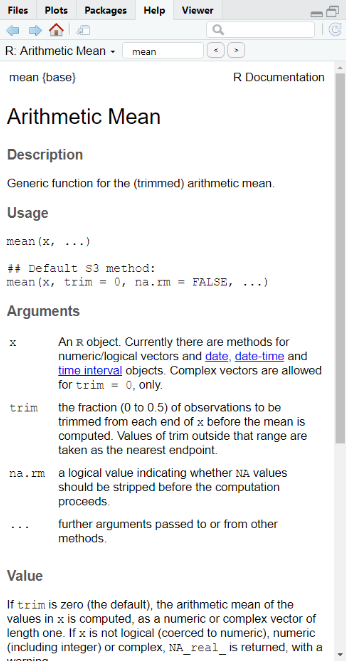

Fig. 3 - Documentação mean()